# PageRank

```
Dhruv Kumar
dkumar2@buffalo.edu
```

## Introduction

In this project, we shall take a ride through an amazing well known algorithm, PageRank which was named after Larry Page, one of the founders of Google. PageRank is a way of measuring the importance of website pages by counting the number of links to a page to determine a rough estimate of how important the website is. The underlying assumption is that more important websites are likely to receive more links from other websites. This by no means is the only algorithm that google uses but is definitely one of the first algorithms that made google what it is today. Don't worry! We are not going to make a search engine like that of google by assigning page ranks to links from a specific location/link because that would consist of mapping the whole network of links in the world wide web. Rather, we are going to look at a very small subset of links which will be the ones in the mathematics website of University at Buffalo. The main link representing the math department at UB is: http://www.buffalo.edu/cas/math.html which consists of user friendly interface with which we can be directed to other links.

The report warms up by extracting the data in the aforementioned link with the help of sending HTTP/1.1 requests which automatically decode content from the server. After that, the report defines a number of helper functions (more information about these later in the project) which will prove useful to compute the page ranks associated to each link in the math website. These functions will help us plot the frequency of link first based on the number of links that can be reached from a specific link and then plotting the links based on the calculated page ranks.

## Procedure

### Prerequisites

These will be the libraries that we will import in order to achive the funcionality we require.

```python
import requests # extracting data from links
import matplotlib.pyplot as plt # useful for plotting purposes
import matplotlib.patches as patches # useful to create patches in a plot
import matplotlib.cm as cm # useful to generate colormap
import re # useful to use regular expressions
import numpy as np # useful for scientific computation using arrays
```

### Helper Functions

The first helper function namely, `page_links()` is fairly trivial. It takes in a link in a variable named *address* as an input and returns a list of links that can be reached from *address* with the help of regular expression as follows:

```python
def page_links(address): # Function header
    return ['http://www.buffalo.edu'+ n for n in re.findall(r'href="(/cas/math[-/\w\d\.]*)', address)]
    #list comprehension and regular expression
```

This function will be useful on our next helper function namely, `site_links()`. This function has the same input as the above function where it takes a link in a variable named *address*. However, the functionality is a bit different. The main aim for this function will be for us to be able to generate a data corresponding to all the links in the websites from math department. What do I mean by that? Well, we shall generate a data that will consist of all the links $l_1, l_2,...,l_n$ corresponding to a list of links that can be reached from these links. Now to do this, we will need some starting point which should be link. This starting point/link will be the input to the function. Let's discuss what the function is actually going to do now. This function will first start by creating a set that will initially consist of the start link, an empty dictionary which will consists of links $l_1, l_2,...,l_n$ as keys and a list of links that can be reached from all the above links as values respectively, and lastly another set which is initally empty. The first set will be to maintain a list of websites that the function will need to visit whereas the second set will maintain a list of links that the function would've visited.

After we've declared an initalized the necessary data structures, we will now move on to describe the process which starts off by a loop which will run as long as the length of `listOfSites` is greater than 0. In each iteration of the loop, we will extract a link from `listOfSites`. The function will then check to see if th extracted link has already been visited or not. If it has, we don't need to bother with it and therefore the funciton continues with the loop. On the contrary, the funtion get's all the links that are reachable from the extracted link. This is done by our helper function,`page_links()` that we defined above. After this, the extracted link and the list of reachable list is added to `dictionary`. Secondly, the extracted link is added to `visitedSite` which is the set of sites that the function will have visited. This makes sense since we've already discovered the extracted link and gotten al the data we need. Lastly, we add those reachable links from the extracted link which have not yet been discovered. After the function exits the loop symbolizing the fact that all the links have been discovered, it simply returns `dictionary`.

```python
def site_links(address):
    listOfSites = {address}
    dictionary = {}
    visitedSite = set()
    while len(listOfSites) > 0:
        addressToConsider = listOfSites.pop()
        if addressToConsider in visitedSite:
            continue
        else:
            listOfLinks = page_links(requests.get(addressToConsider).text)
            dictionary[addressToConsider] = listOfLinks
            visitedSite.add(addressToConsider)
            listOfSites = listOfSites | (set(listOfLinks)-visitedSite)
    return dictionary
```

Last but equally import helper function `plot_func()` will be used to create a plot consisting of points with coordinates (i,j) if there is a link from the page $P_i$ to the page $P_j$. Different colors will used to indicate how many links are between given two pages. This function takes in two arguments namely, `dictOfLinksAndIndex` and `plotHeader`. The first argument is simply a dictionary that will consist of all the links that we've discovered as keys and a number or index if you may assigned to each link as the values respectivily. The second argument will just be a string for the header of the plot. This is taken in as an argument because this function will be used to generate 2 plots like mentioned in the introduction where they will represent different data.

This function starts by declaring the figure size, limits for x and y, axis for the plot, color sceme, and the background color of the plot. After that, a loop is declared to iterate over the dictionary taken in as the argument. In each iteration, we get the number corresponding to the link currently being considered which will be the x value for the point to be plotted. After that, we extract all the links that are reachable form the link being considered. Then, another loop is ran on the list of reachable links. In each iteration of that loop, the function plot extracts the y value for the point to be plotted which corresponds to the number/index of each reachable link. This can be extracted from the dictionary taken in as the input. The point is then plotted with x and values along with the radius of the circle/point to be plotted and the color. For the color aspect, we stay within the bounds of the second loop where we take each link and see how many times it appears in the list of reachable links. Then based on this number, the color of the circle/point is determined. Lastly, we create a legend that tells the reader about how many links each color corresponds to. This functionality is achived by running yet another loop which is independent of the first two loops. In each iteration of this loop, we simply create a label which corresponds to the number of links and the color which will be the color of the points. There will only be 5 distinct colors whereas the last value will simply be greater than or equal to 5 links.

```python
def plot_func(dictOfLinksAndIndex, string):
    plt.figure(figsize=(35,30))
    plt.title(string,fontsize=80)
    plt.xlim(0, len(index_links))
    plt.ylim(0, len(index_links))
    ax = plt.axes()
    ax.set_axis_bgcolor('black')
    cmap = cm.jet
    for link in dictOfLinksAndIndex:
        x = dictOfLinksAndIndex[link]
        listOfLinks = data[link]
        for outgoingLinks in listOfLinks:
            numOfLinks = listOfLinks.count(outgoingLinks)
            c = cmap(0.2*numOfLinks)
            circle_patch = patches.Circle((x, dictOfLinksAndIndex[outgoingLinks]), radius = 0.2,color= c)
            ax.add_patch(circle_patch)
    for i in range(1,5):
        plt.plot([],[],marker='o', ms = 40, color = cmap(0.2*i), label = str(i))
    plt.plot([],[],marker='o', ms = 40, color = cmap(0.2*5), label = '>= '+str(5))
    plt.legend(loc='center left', bbox_to_anchor=(1, 0.5), prop={'size':40})
    plt.show()
```

### Assessment

Now that we've taken care of the prerequisites and helper functions, we can move on to calculating the page ranks and plotting the data. To do something, there needs to exist a starting point and this will need to have that as well. First step for us will be to determine a starting point and to make it easier, we shall choose the main math website (Let's call it $W_1$). After this, we will need to determine all the reachable links from the starting point. Fortunately for us, we can simply use our first helper function `page_links()`. We will achive this functionality as follows:

```python
page = requests.get('http://www.buffalo.edu/cas/math.html')
```

```python
temp = page_links(page.text)
len(temp)
```

```
106
```

It works! The `temp` variable now has all the reachable links $l_1,l_2,....,l_n$ from $W_1$ and as we can see, there are 106 links that can be reached from this link alone. `temp` won't be used in the report from this point on. This was mearly to check if the function provides us with the required functionality that we require.

We will now need to get reachable links from all the links $l_1,l_2,....,l_n$. This can be done by using yet another helper function `site_links()` that will return us a dictionary with every link in the website of math department as keys and lists of reachable links for every key respectively. This will again need a starting point which will be $W_1$.

```python
data = site_links('http://www.buffalo.edu/cas/math.html')
```

```python
len(data)
```

```
158
```

The final number is 158. This means that there are a total of 158 links in the website of math department. Each of this link will have numerous reachable links which can be found by the helper function `page_links()` like we did above for $W_1$. We can now plot these links but it would be a bit tedious to be able to plot all the links without any integers being associated to them. For this reason, we shall assign each link a number/index. This number will represent a specific link. To achive this, a snipet of code is written which declares and initializes an empty dictionary. This dictionary will have all the links as the keys and the number associated to them as their values. A counter i is also declared which is exentially the number that is going to be assigned to each link. Lastly, a loop is declared to iterate over the all the links in the website of math department and in each iteration we simply assign the link being considered the counter and increment the counter by 1.

```python
index_links = {}
i = 0
for link in data.keys():
    index_links[link] = i
    i += 1
```

Since the python dictionary is unordered. We shall sort the links based on the number assigned to them. This will be for our visualization so we could know each link and the number associated to it. It is achived by first converting the dictionary to a list of tuples and then sorting it based on the value in the first index of every tuple which is esentially the number associated to the links. The code to achive this is as follows:

```python
listOfIntexLinks = list(index_links.items())
sortedIndexLink = sorted(listOfIntexLinks , key=lambda k: k[1])
sortedIndexLink
```

```
[('http://www.buffalo.edu/cas/math/people/faculty/menasco.html', 0),
 ('http://www.buffalo.edu/cas/math/grad/fellowships-awards.html', 1),
 ('http://www.buffalo.edu/cas/math/about-us/the-buffalo-niagara-region.host.html/content/shared/university/page-content/the-buffalo-niagara-region/affordable-living.host.html/content/shared/university/page-content/the-buffalo-niagara-region/weather--a-four-season-region1.detail.html',
  2),
 ('http://www.buffalo.edu/cas/math/news-events/visiting.html', 3),
 ('http://www.buffalo.edu/cas/math/people/faculty/mangahas.html', 4),
 ('http://www.buffalo.edu/cas/math/about-us/our-mission.html', 5),
 ('http://www.buffalo.edu/cas/math/people.html', 6),
 ('http://www.buffalo.edu/cas/math/people/faculty/hlee.html', 7),
 ('http://www.buffalo.edu/cas/math/people/faculty/faran.html', 8),
 ('http://www.buffalo.edu/cas/math/people/staff_directory.html', 9),
 ('http://www.buffalo.edu/cas/math/news-events/news/menasco-knots.html', 10),
 ('http://www.buffalo.edu/cas/math/about-us/our-alumni/our-students.host.html/content/shared/cas/math/modules/our-students/summer-scholarship.detail.html',
  11),
 ('http://www.buffalo.edu/cas/math/people/faculty/zhang.html', 12),
 ('http://www.buffalo.edu/cas/math/ug.html', 13),
 ('http://www.buffalo.edu/cas/math/people/faculty/cusick.html', 14),
 ('http://www.buffalo.edu/cas/math/people/faculty/cchou.html', 15),
 ('http://www.buffalo.edu/cas/math/news-events/myhill/Peter-Sarnak.html', 16),
 ('http://www.buffalo.edu/cas/math/about-us/our-alumni/our-alumni.host.html/content/shared/cas/math/modules/our-alumni/thompson.detail.html',
  17),
 ('http://www.buffalo.edu/cas/math/apply.html', 18),
 ('http://www.buffalo.edu/cas/math/news-events/archives.html', 19),
 ('http://www.buffalo.edu/cas/math/grad/doctoral-program.html', 20),
 ('http://www.buffalo.edu/cas/math/courses.html', 21),
 ('http://www.buffalo.edu/cas/math/about-us/our-alumni/our-alumni.html.host.html/content/shared/cas/math/modules/our-alumni/burzik.detail.html',
  22),
 ('http://www.buffalo.edu/cas/math/about-us/the-buffalo-niagara-region.host.html/content/shared/university/page-content/the-buffalo-niagara-region/things-to-do-in-buffalo/history.detail.html',
  23),
 ('http://www.buffalo.edu/cas/math/about-us/the-buffalo-niagara-region.host.html/content/shared/university/page-content/the-buffalo-niagara-region/things-to-do-in-buffalo/recreation_and_leisure.detail.html',
  24),
 ('http://www.buffalo.edu/cas/math/about-us/why-choose.html', 25),
 ('http://www.buffalo.edu/cas/math/people/faculty/kutluhan.html', 26),
 ('http://www.buffalo.edu/cas/math/information-for-faculty-staff.html', 27),
 ('http://www.buffalo.edu/cas/math/news-events/myhill/percy-deift.html', 28),
 ('http://www.buffalo.edu/cas/math/about-us/the-buffalo-niagara-region.host.html/content/shared/university/page-content/the-buffalo-niagara-region/affordable-living.host.html/content/shared/university/page-content/the-buffalo-niagara-region/things-to-do-in-buffalo.detail.html',
  29),
 ('http://www.buffalo.edu/cas/math/about-us/our-alumni/our-students.host.html/content/shared/cas/math/modules/our-students/awards16.detail.html',
  30),
 ('http://www.buffalo.edu/cas/math/about-us/the-buffalo-niagara-region.host.html/content/shared/university/page-content/the-buffalo-niagara-region/weather--a-four-season-region1.detail.html',
```

[output cut: 174 more lines]

```
 ('http://www.buffalo.edu/cas/math/people/memoriam.html', 147),
 ('http://www.buffalo.edu/cas/math/news-events/news.host.html/content/shared/cas/math/modules/our-students/awards16.detail.html',
  148),
 ('http://www.buffalo.edu/cas/math/people/faculty/sageev.html', 149),
 ('http://www.buffalo.edu/cas/math/about-us/our-alumni/our-students.html',
  150),
 ('http://www.buffalo.edu/cas/math/people/faculty/xia.html', 151),
 ('http://www.buffalo.edu/cas/math/about-us/the-buffalo-niagara-region.host.html/content/shared/university/page-content/the-buffalo-niagara-region/getting_around.detail.html',
  152),
 ('http://www.buffalo.edu/cas/math/about-us/our-alumni/our-faculty.html', 153),
 ('http://www.buffalo.edu/cas/math/news-events/news.host.html/content/shared/cas/math/modules/faculty15/hanfeng-li.detail.html',
  154),
 ('http://www.buffalo.edu/cas/math/research/geometry-topology.html', 155),
 ('http://www.buffalo.edu/cas/math/ug/math-help/aleks.html', 156),
 ('http://www.buffalo.edu/cas/math/people/faculty.html', 157)]
```

Now that we have each link associated to a number, we can finally plot the data. For this, we will use our last helper function `plot_func()` to plot this data.

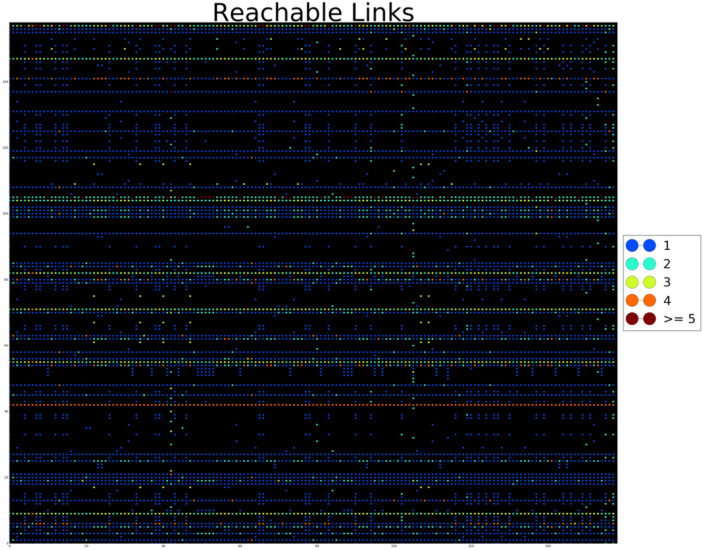

```python
plot_func(index_links, "Reachable Links")
```

Lastly, we will calculate the page ranks for each of the 158 links and plot the links based on the page ranks. PageRank algorithm is a method for ranking webpages. This algorithm assigns to each page P in some network of webpages its ranking which is a number $0\leq r(P) \leq 1$. Higher ranking is supposed to indicate a more significant page in the network. PageRank ranking of a webpage is computed as follows. Assume that $l_1,l_2,...,l_k$ are all links pointing to a page P, where the link $l_i$ starts on a page $P_i$. We set:

$r(P) = \sum\limits_{i=1}^k \frac{r(P_i)}{n(P_i)}$

where: $r(P_i)$ is the PageRank of the webpage and $n(P_i)$ is the number of all links originating from $P_i$.In addition, PageRank rankings must satisfy the condition that if $P_1,P_2,...,P_N$ are all pages in the network then $r(P_1)+...+r(P_N)=1$

We clculate this with the help of `numpy.linalg.lstsq` in python that return the least-squares solution to a linear matrix equation. The matrix in our case will be generate with the help of equations that are going to be derived based on the forumla above where each link will have certain amount of reachable links. The last row of the matrix will consist of all ones since the sum of all the rankings can not be greater than 1. Apart from that, the diagonal will also consist of all ones and this is because each link is reachable to itself. This will be the base matrix of A. After this, we shall edit each element of the matrix in accordance with the equation corresponding to it. Each row in this matrix will esentially correspond to an equation generated from the data of reachable links for all $l_1,l_2,....,l_k$ links. The *b* in equation `Ax = b` will be a list of all 0's except the last element which will be a 1. All the elements are 0's because we are considering the equations where everything is on the left-hand side. This will result in every equation to be equal to 0 and the last element is a 1 because as discussed above, the sum of all links cannot be greate than 1.

```python
A = np.zeros((len(index_links)+1,len(index_links)))
```

```python
A[len(index_links)] = 1
```

```python
for i in range(len(index_links)):
    A[i][i] = 1
```

```python
b = np.zeros(len(index_links)+1)
```

```python
b[len(index_links)] = 1
```

Now, that we have our base matrix A and b. We can start editing A in accordance with the equation. Writing all the equations will be a bit tedious. Due to this, we will make use of a simple formula that is implimented in the code below:

```python
for link in index_links.keys():
    indexOfLink = index_links[link]
    outgoingLinks = data[link]
    for outgoingLink in outgoingLinks:
        A[index_links[outgoingLink]][indexOfLink] -= (1/len(outgoingLinks))
```

```python
sol = np.linalg.lstsq(A, b)
```

This `sol` will consist of 4 things but we will only need to worry about the value in the first index which gives us the least square solution of the equation Ax = b. This gives the Page ranks that we require in form of a numpy array with one entry for each page. Each index of this list will correspond to a number that is associated to a list.

```python
pageRanks = sol[0]
```

We shall now assign each link it's page ranking and it is done by creating a dictionary where the keys are the links that the values are the page ranking respectivily. A loop is ran over all the page ranking aquired from sol[0] and with the help of the index of each ranking, we aquire the link from index_links that was defined above.

```python
pageRankDict = {}
for link in index_links:
    pageRankDict[link] = pageRanks[index_links[link]]
```

Now we are going to repeat the same process as we did before by assigning each link a number so that we can plot the data. Last time we were randomly assigning numbers to the links but this time we need to be careful. So, we simply order each link based on their page ranks from highest to lowest. This means that the link with highest page ranking should be on index 0, the second highest page ranking link should be on index 1 and so on. We know that the dictionary is unordered so we repeat the same process as we did before and change the dictionary to a list of tuples. After this, we simply order the tuples based on the value on index 1 which will esentially correspond to the page rankings. After we've done that, we can simply assign each link a number replacing the value of page ranking with that number. This number can be a ocunter that iterates over the list and will give 0 to the link with highest page ranking, 1 to the second and so on. Lastly we will convert the list of tuples to a dictionary and call our function `plot_func()` to plot all the links based on their page rankings. All of this functionality will be achived in three lines where the first line will convert the dictionary to a list and sort the links based on page ranking. The second line will simply replace each ranking with a number that we want to associate to each link by maintaining a counter. The third and last line will change the list back to a dictionary.

```python
sortedPageRankDict = sorted(list(pageRankDict.items()), reverse = True, key=lambda k: k[1])
sortedPageRankDict = [(link[1][0] , link[0]) for link in enumerate(sortedPageRankDict)]
sortedPageRankDict = dict(sortedPageRankDict)
```

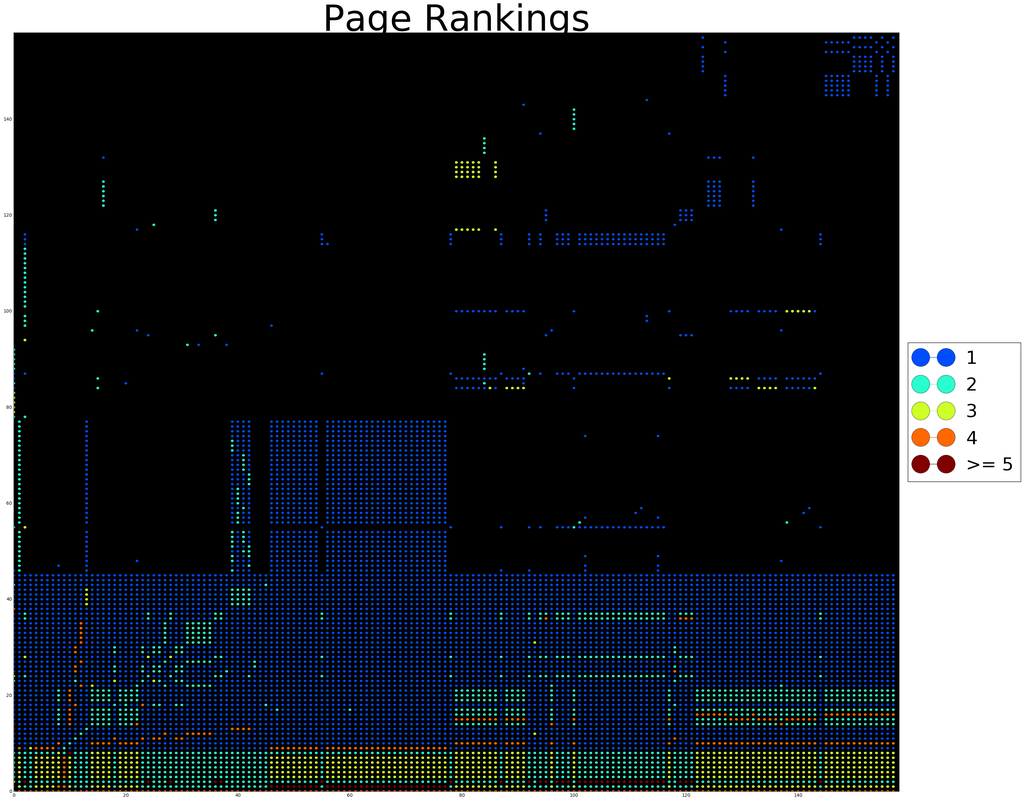

```python
plot_func(sortedPageRankDict, "Page Rankings")
```

```python
def topLinks(links):
    topLinks = []
    i = 0
    for link in sortedPageRankDict:
        topLinks.append((link[0],i))
        i += 1
        if i == 20:
            return topLinks
sortedPageRankDict = sorted(list(pageRankDict.items()), reverse = True, key=lambda k: k[1])
topLinks(sortedPageRankDict)
```

```
[('http://www.buffalo.edu/cas/math.html', 0),
 ('http://www.buffalo.edu/cas/math/people/faculty.html', 1),
 ('http://www.buffalo.edu/cas/math/news-events/news.html', 2),
 ('http://www.buffalo.edu/cas/math/people/memoriam.html', 3),
 ('http://www.buffalo.edu/cas/math/people/staff_directory.html', 4),
 ('http://www.buffalo.edu/cas/math/people/grad-directory.html', 5),
 ('http://www.buffalo.edu/cas/math/people/instructors.html', 6),
 ('http://www.buffalo.edu/cas/math/people/emeritus.html', 7),
 ('http://www.buffalo.edu/cas/math/about-us/contact-us.html', 8),
 ('http://www.buffalo.edu/cas/math/people.html', 9),
 ('http://www.buffalo.edu/cas/math/about-us.html', 10),
 ('http://www.buffalo.edu/cas/math/ug.html', 11),
 ('http://www.buffalo.edu/cas/math/grad.html', 12),
 ('http://www.buffalo.edu/cas/math/research.html', 13),
 ('http://www.buffalo.edu/cas/math/about-us/Memberships.html', 14),
 ('http://www.buffalo.edu/cas/math/about-us/our-alumni.html', 15),
 ('http://www.buffalo.edu/cas/math/about-us/the-buffalo-niagara-region.html',
  16),
 ('http://www.buffalo.edu/cas/math/about-us/community-outreach.html', 17),
 ('http://www.buffalo.edu/cas/math/ug/math-help.html', 18),
 ('http://www.buffalo.edu/cas/math/about-us/our-mission.html', 19)]
```

## Observation

As it can be seen above in the plot, all the dots that are colored brown are in the bottom of the plot and then as we go above the plot, the color cools down a bit such that the reachable links is lesser. The page rankings of links that are in the lower part of the plot are esentially larger. This means that the links with higher page ranking has higher reachable link material. This makes sense since as seen above, http://www.buffalo.edu/cas/math.html is the link with highest page ranking as it is essentially the start page that we used in the beginning and the page that opens up when you visit the math website. Also, the majority if not all the brown circles/dots are on the index 0 as it is the most important one and has most number of reachable link to another link. After that from index 1-2 to 10, the plot can be seen to have majority of green and teal circles/dots. These constitues to the links that provide sub informaiton and the oppertunities in the department with news events, staff and grad directory, information on instructors, people and etc. From that point on the plot consists of blue circles/dots with some disrepsency.

## Conclusion

We've successfully calculated the page rankings for each link in the website of the math department and plotted those links based on the links that go from that link to another and based on their respective page rankings.